# Analysis Candidate Experiment Data with OLS, Logistic Model and Conditional Logistic Model, Plus Clustering

Wei-Lun, Lin

2025-12-17

## Candidate Experiment

```r
candidate <- read_rds("../1-data/2-processed/candidate_data.rds")
candidate %>%
  head() %>%
  kable("html", caption="First 6 Row of Candidate Data") %>%
  kable_styling(bootstrap_options = c("striped", "hover", "condensed"), full_width = F) %>%
  scroll_box(width = "100%")
```

First 6 Row of Candidate Data

| subject | trial_id | profile_id | select | MilitaryService. | Religion. | College. | Profession. | Income. | RaceEthnicity. | Age. | Gender. | rating |
| --- | --- | --- | --- | --- | --- | --- | --- | --- | --- | --- | --- | --- |
| A2NEN4NSNS2O8S | 1 | 173627 | 0 | Did Not Serve | Mormon | Community college | Car dealer | 5.1M | White | 75 | Female | 0.3333333 |
| A2NEN4NSNS2O8S | 1 | 60698 | 1 | Served | None | No BA | High school teacher | 65K | Asian American | 60 | Male | 0.5000000 |
| A2NEN4NSNS2O8S | 2 | 158453 | 1 | Did Not Serve | Catholic | Small college | Farmer | 32K | Native American | 68 | Female | 0.6666667 |
| A2NEN4NSNS2O8S | 2 | 78392 | 0 | Served | Mainline protestant | Small college | Doctor | 54K | White | 75 | Male | 0.6666667 |
| A2NEN4NSNS2O8S | 3 | 113774 | 0 | Served | None | Baptist college | Doctor | 5.1M | Native American | 45 | Female | 0.3333333 |
| A2NEN4NSNS2O8S | 3 | 31616 | 1 | Served | Mainline protestant | No BA | Lawyer | 54K | White | 52 | Male | 0.5000000 |

在 candidate experiment 中，candidate 有8個 attributes:

[output not shown]

## Model Fitting

```r
est.all.candidate <- data.frame()
```

### Candidate: Linear Regression

```r
ols.candidate <- fit_model(
  select ~ MilitaryService. + Religion. + College. + Profession. + Income. + RaceEthnicity. + Age. + Gender.,
  dat = candidate, model = "ols"
)
ols_clus.candidate <- fit_model(
  select ~ MilitaryService. + Religion. + College. + Profession. + Income. + RaceEthnicity. + Age. + Gender.,
  dat = candidate, model = "ols", cluster = "subject"
)

est.all.candidate <- ols.candidate[[2]] %>%
  select(-c(statistic, p.value)) %>%
  mutate(
    CI.lower = estimate - 1.96*std.error,
    CI.upper = estimate + 1.96*std.error
  ) %>%
  rename_with(~ paste0(.x, ".OLS"), .cols = -c(attribute, term))
est.all.candidate <- ols_clus.candidate[[2]] %>%
  select(-c(statistic, p.value)) %>%
  mutate(
    CI.lower = estimate - 1.96*std.error,
    CI.upper = estimate + 1.96*std.error
  ) %>%
  rename_with(~ paste0(.x, ".OLS_clustered"), .cols = -c(attribute, term)) %>%
  left_join(est.all.candidate, ., by = join_by(attribute, term))
```

Plot the result of OLS, including clustered at subject and without clustering.

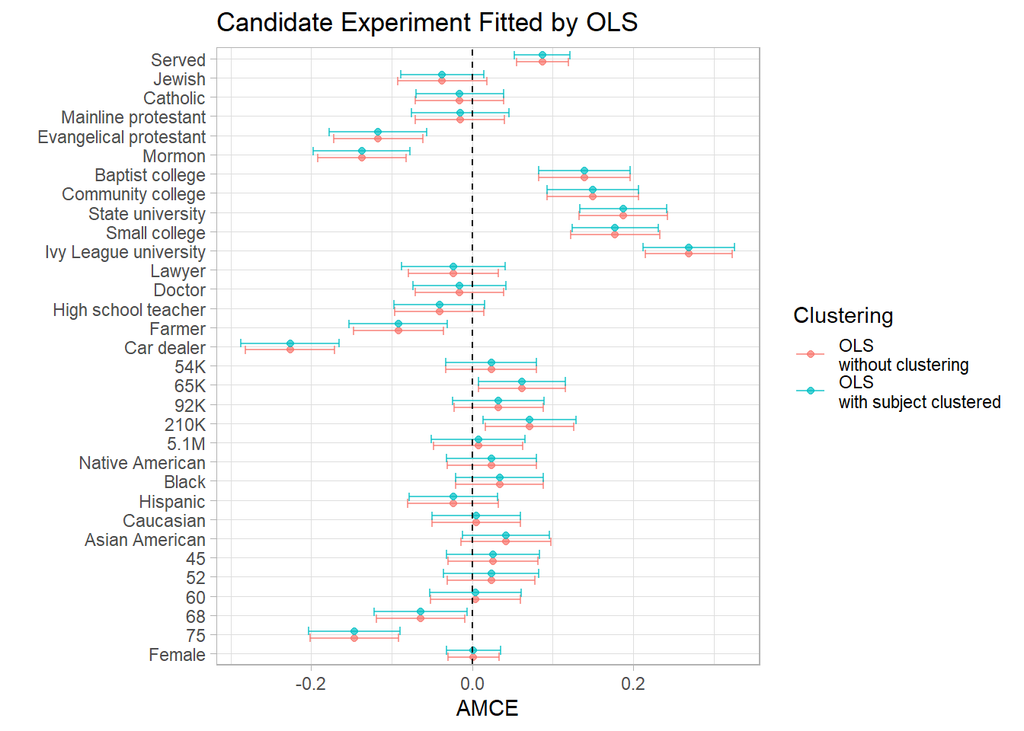

```r
ols.plot.candidate <- est.all.candidate %>%
  select(c(attribute, term, contains("OLS"))) %>%
  select(c(attribute, term, starts_with("estimate."), starts_with("CI."))) %>%
  mutate(term = factor(term, levels = rev(term))) %>%
  pivot_longer(
    cols = -c(attribute, term),
    names_to = c(".value", "model"),
    names_pattern = "(.*)\\.(OLS|OLS_clustered)$"
  ) %>%
  mutate(
    model = fct_recode(model, "OLS\nwithout clustering" = "OLS", "OLS\nwith subject clustered" = "OLS_clustered")
  ) %>%
  plot_result(., n.mod = 2) +
  labs(title = "Candidate Experiment Fitted by OLS", x = "AMCE", color="Clustering")

ggsave("./1-figure/res-candidate-OLS.png", ols.plot.candidate)

ols.plot.candidate
```

### Logistic Regression

```r
logit.candidate <- fit_model(
  select ~ MilitaryService. + Religion. + College. + Profession. + Income. + RaceEthnicity. + Age. + Gender.,
  dat = candidate, model = "logit"
)
logit_clus.candidate <- fit_model(
  select ~ MilitaryService. + Religion. + College. + Profession. + Income. + RaceEthnicity. + Age. + Gender.,
  dat = candidate, model = "logit", cluster = "subject"
)

est.all.candidate <- logit.candidate[[2]] %>%
  select(-c(statistic, p.value)) %>%
  mutate(
    CI.lower = estimate - 1.96*std.error,
    CI.upper = estimate + 1.96*std.error
  ) %>%
  rename_with(~ paste0(.x, ".logit"), .cols = -c(attribute, term)) %>%
  left_join(est.all.candidate, ., by = join_by(attribute, term))
est.all.candidate <- logit_clus.candidate[[2]] %>%
  select(-c(statistic, p.value)) %>%
  mutate(
    CI.lower = estimate - 1.96*std.error,
    CI.upper = estimate + 1.96*std.error
  ) %>%
  rename_with(~ paste0(.x, ".logit_clustered"), .cols = -c(attribute, term)) %>%
  left_join(est.all.candidate, ., by = join_by(attribute, term))
```

Plot the result of logistic regression.

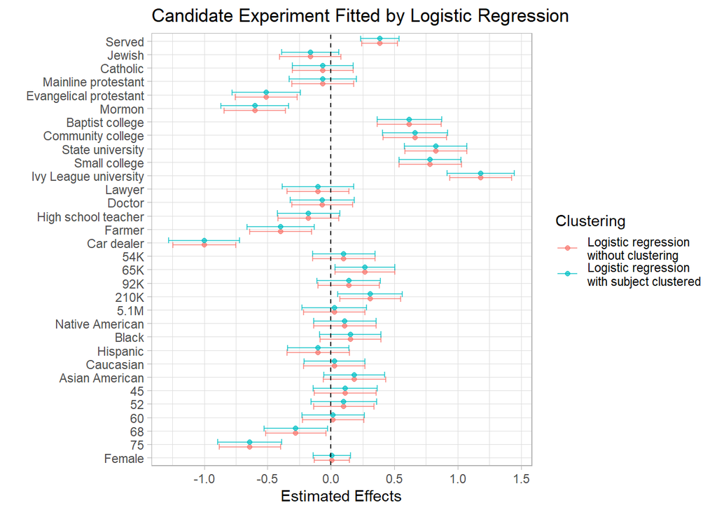

```r
logit.plot.candidate <- est.all.candidate %>%
  select(c(
    attribute, term, (
      contains("logit") & (starts_with("estimate.") | starts_with("CI."))
    )
  )) %>%
  mutate(term = factor(term, levels = rev(term))) %>%
  pivot_longer(
    cols = -c(attribute, term),
    names_to = c(".value", "model"),
    names_pattern = "(.*)\\.(logit|logit_clustered)$"
  ) %>%
  mutate(
    model = fct_recode(
      model,
      "Logistic regression\nwithout clustering" = "logit",
      "Logistic regression\nwith subject clustered" = "logit_clustered"
    )
  ) %>%
  plot_result(., n.mod = 2) +
  labs(title = "Candidate Experiment Fitted by Logistic Regression", x = "Estimated Effects", color="Clustering")

ggsave("./1-figure/res-candidate-logit.png", logit.plot.candidate)
logit.plot.candidate
```

### Conditional Logistic Regression

```r
# original conditional logistic regression
cl.candidate <- fit_model(
  select ~ MilitaryService. + Religion. + College. + Profession. + Income. + RaceEthnicity. + Age. + Gender. + strata(trial_id),
  dat = candidate, model = "clogit"
)
cl_clus.candidate <- fit_model(
  select ~ MilitaryService. + Religion. + College. + Profession. + Income. + RaceEthnicity. + Age. + Gender. + strata(trial_id),
  dat = candidate, model = "clogit", is_cluster = T
)

est.all.candidate <- cl.candidate[[2]] %>%
  select(-c(statistic, p.value)) %>%
  mutate(
    CI.lower = estimate - 1.96*std.error,
    CI.upper = estimate + 1.96*std.error
  ) %>%
  rename_with(~ paste0(.x, ".CL"), .cols = -c(attribute, term)) %>%
  left_join(est.all.candidate, ., by = join_by(attribute, term))
est.all.candidate <- cl_clus.candidate[[2]] %>%
  select(-c(statistic, p.value)) %>%
  mutate(
    std.error = robust.se,
    CI.lower = estimate - 1.96*std.error,
    CI.upper = estimate + 1.96*std.error
  ) %>%
  select(-robust.se) %>%
  rename_with(~ paste0(.x, ".CL_clustered"), .cols = -c(attribute, term)) %>%
  left_join(est.all.candidate, ., by = join_by(attribute, term))
```

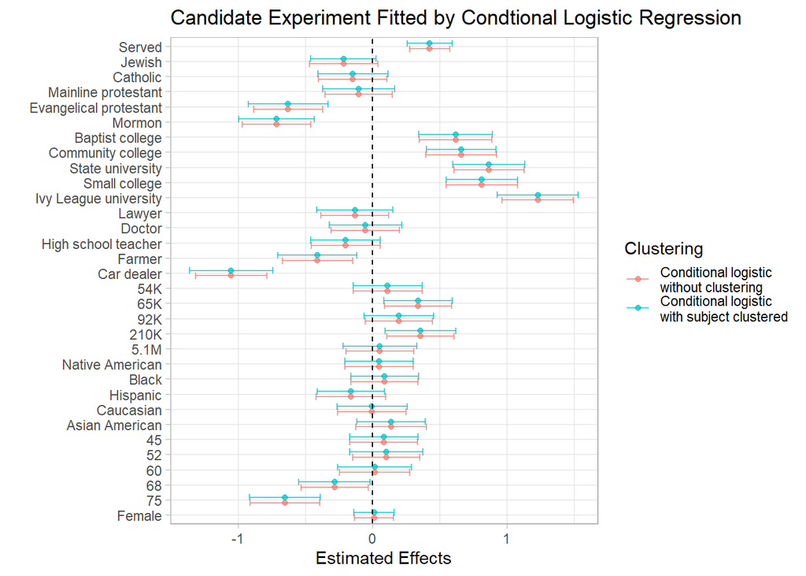

```r
cl.plot.candidate <- est.all.candidate %>%
  select(c(
    attribute, term, (
      contains("CL", ignore.case = F) & (starts_with("estimate.") | starts_with("CI."))
    )
  )) %>%
  mutate(term = factor(term, levels = rev(term))) %>%
  pivot_longer(
    cols = -c(attribute, term),
    names_to = c(".value", "model"),
    names_pattern = "(.*)\\.(CL|CL_clustered)$"
  ) %>%
  mutate(
    model = fct_recode(
      model,
      "Conditional logistic\nwithout clustering" = "CL",
      "Conditional logistic\nwith subject clustered" = "CL_clustered"
    )
  ) %>%
  plot_result(., n.mod = 2) +
  labs(title = "Candidate Experiment Fitted by Condtional Logistic Regression", x = "Estimated Effects", color="Clustering")

ggsave("./1-figure/res-candidate-CL.png", cl.plot.candidate)
cl.plot.candidate
```

## Result Comparison

### Logistic and Conditional Logistic Regression w/ and w/o Clustering

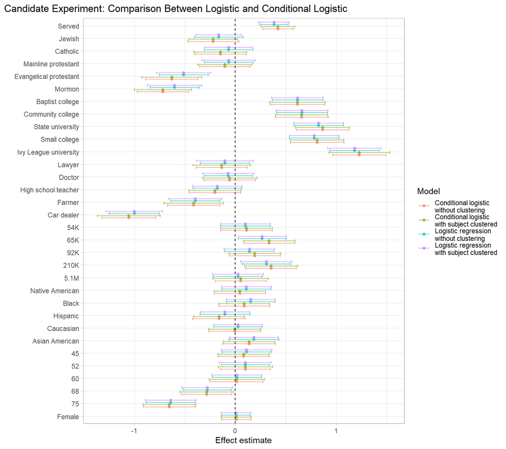

```r
est.all.candidate %>%
  select(-contains("OLS")) %>%
  mutate(term = factor(term, levels = rev(term))) %>%
  pivot_longer(
    cols = -c(attribute,term),
    names_to = c(".value", "model"),
    names_pattern = "(.*)\\.(logit.*|CL.*)$"
  ) %>%
  mutate(
    model = fct_recode(
      model,
      "Logistic regression\nwithout clustering" = "logit",
      "Logistic regression\nwith subject clustered" = "logit_clustered",
      "Conditional logistic\nwithout clustering" = "CL",
      "Conditional logistic\nwith subject clustered" = "CL_clustered"
    )
  ) %>%
  plot_result(., n.mod=4) +
  labs(
    x = "Effect estimate", col="Model",
    title = "Candidate Experiment: Comparison Between Logistic and Conditional Logistic"
  ) +
  theme(
      # legend.position = "bottom",
      plot.title.position = "plot"
    )
```

```r
ggsave("./1-figure/res-candidate-BL+CL.png")
```

Robust se 的膨脹程度通常可以由 Moulton factor 做近似:

$$\frac{SE_{robust}}{SE_{standard}} \approx \sqrt{1+(n-1)\rho_x
\rho_\varepsilon}$$

，其中 $n$ 是 cluster size，$\pho_x$ 是 attributes 在 cluster 內部的相關性，而 $\rho_\varepsilon$ 則是殘差的相關性。

由於 conjoint experiment 的 randomization 設計，使得每位受試者觀察到的 attributes 之間不存在相關性， 因此 Moulton factor 會約為 1，說明了原本的 standard error 和 cluster-robust standard error 之間為何差異不大。